# MSB7102 Mini-project, Semester I, 2021

Arthur Shem Kasambula

6/25/2021

# Background

The data used in this exercise is derived and was generated by Kolistic et al in their study “The dynamics of the human infant gut microbiome in development and progression toward Type 1 Diabetes”. See full publication at [here](https://doi.org/10.1016/j.chom.2015.01.001). Briefly, this was a prospective analysis of developing gut microbiome in infants en route to type 1 diabetes. Infants from Finland and Estonia were recruited at birth based on predisposition to autoimmunity determined by human leukocyte antigen (HLA) genotyping. The cohort consists of 33 infants, 11 of which seroconverted to serum autoantibody positivity and of those, four developed T1D within the three-year time-frame of this study.

# Tasks

*1*. *Import the data described above into R, provide descriptive summaries of the subject data (using appropriate graphics and statistical summary measures) given in the diabimmune_16s_t1d_metadata.csv file*. *In addition, use appropriate test(s) to check for association/independency between disease status and other variables (delivery mode, gender and age)*. *Note that age is given in days*.

*2*. *Using phyloseq, create a phyloseq object. This will comprise the OTU abundance, taxonomy (provided in the .txt file) and sample data (provided in the .csv file)*.

*3*. *Generate Alpha diversity plots and ordination plots. Examine any observed patterns by delivery mode, gender and disease status*.

*4*. *Perform differential abundance using DEseq2*.

# Answers

```r
#loading the required packages
library(readr)
library(dplyr)
library(viridis)
library(tidyverse)
library(gtsummary)
library(phyloseq)
library(ggplot2)
library(DESeq2)
```

The files to be imported include the diabimmune_16s_t1d_metadata.csv and the diabimmune_t1d_16s_otu_table.txt

### Descriptive analysis

The total number of participants in the study were 33. Out of which 18(55%) were females and 15(45%) were males as shown in table1 below. Majority of the participants 30(91%) were delivered by the vaginal route and very few participants 3(9.1%) were delivered by cesarian section. Among the 33 only 11(33%) were cases. The median number of samples collected from each participant was 23 while the minimum and maximum number of samples collected from each participant was 8 and 34 respectively.

**Table1** **Showing characteristics of the participants**

| **Characteristic** | **N = 33**<sup>1</sup> |
| --- | --- |
| Gender |  |
| female | 18 (55%) |
| male | 15 (45%) |
| Delivery route |  |
| cesarian | 3 (9.1%) |
| vaginal | 30 (91%) |
| Disease status |  |
| case | 11 (33%) |
| control | 22 (67%) |
| Samples | 23 (8,34) |

<sup>*1*</sup> n (%); Median (Minimum,Maximum)

## Samples collected

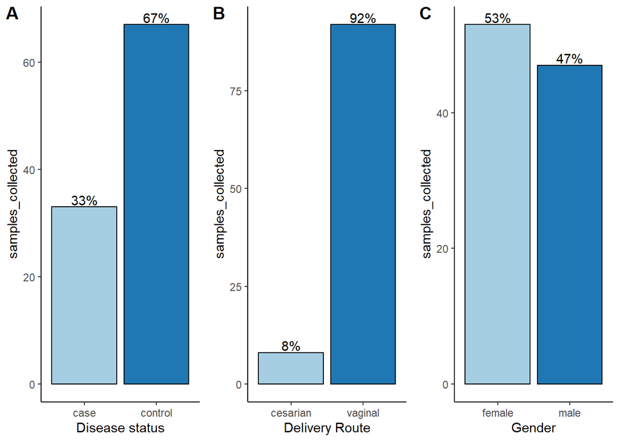

**A.** *Samples collected by disease status* **B.** *Samples collected by delivery route* **C.** *Samples collected by gender*

**Table2** *Showing a summary of samples collected*

| **Characteristic** | **N = 777**<sup>1</sup> |
| --- | --- |
| Age (days) | 452 (6,1,233) |
| Gender |  |
| female | 412 (53%) |
| male | 365 (47%) |
| Delivery route |  |
| cesarian | 66 (8.5%) |
| vaginal | 711 (92%) |
| Disease status |  |
| case | 260 (33%) |
| control | 517 (67%) |

<sup>*1*</sup> Median (Minimum,Maximum); n (%)

**Distribution of age at sample collection**

**Figure D**

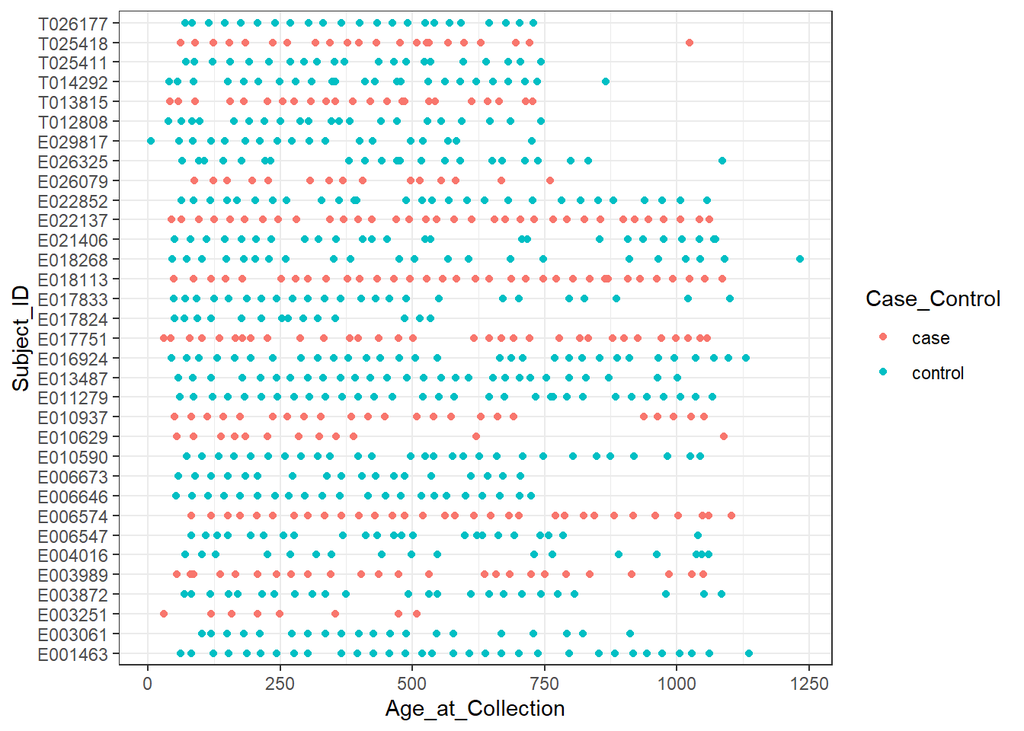

**Figure E**

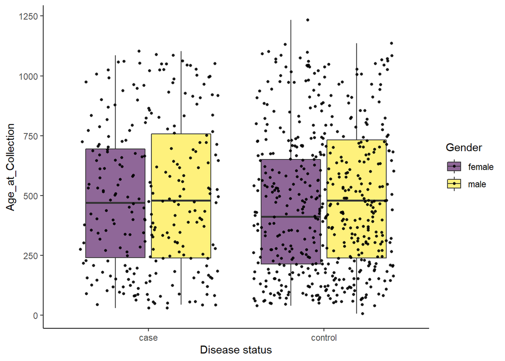

**Figure** **D** *and* **E** *showing distribution of age at sample collection*

**Testing for independence between the variables**

The independence between disease status and other variables was tested using the chi-square test. This reveals that disease status is influenced by the delivery route (p<0.001) as shown in table 3 below.

**Table3** *Showing p-values*

| **Characteristic** | **case**, N = 260<sup>1</sup> | **control**, N = 517<sup>1</sup> | **p-value**<sup>2</sup> |
| --- | --- | --- | --- |
| Gender |  |  | 0.5 |
| female | 142 (55%) | 270 (52%) |  |
| male | 118 (45%) | 247 (48%) |  |
| Delivery route |  |  | <0.001 |
| cesarian | 0 (0%) | 66 (13%) |  |
| vaginal | 260 (100%) | 451 (87%) |  |

<sup>*1*</sup> n (%) <sup>*2*</sup> Pearson's Chi-squared test

**Plots showing Alpha diversity**

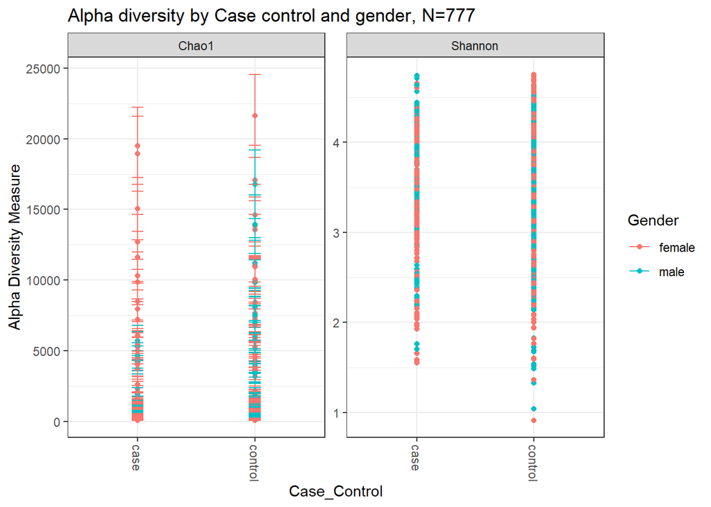

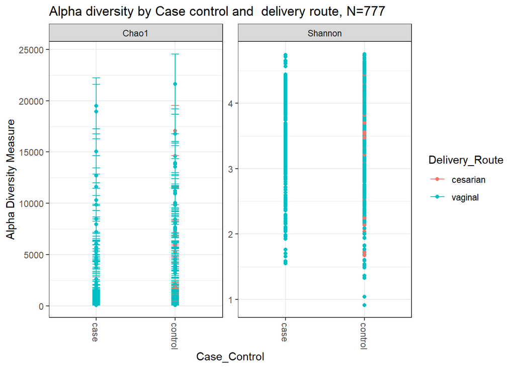

**Ordination plots**

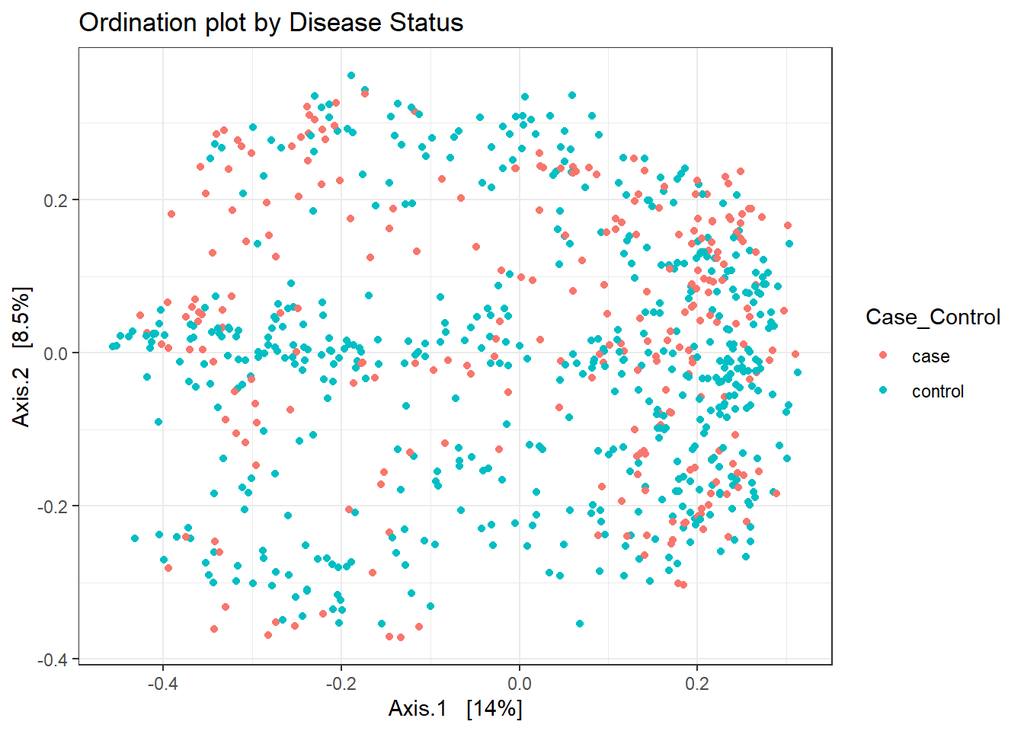

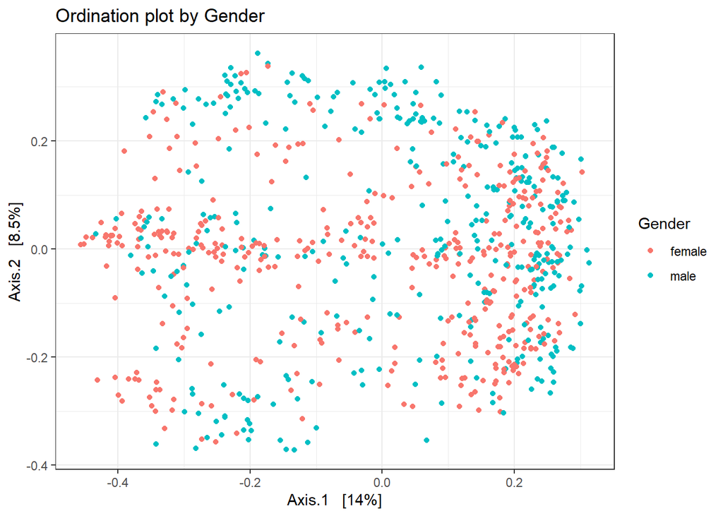

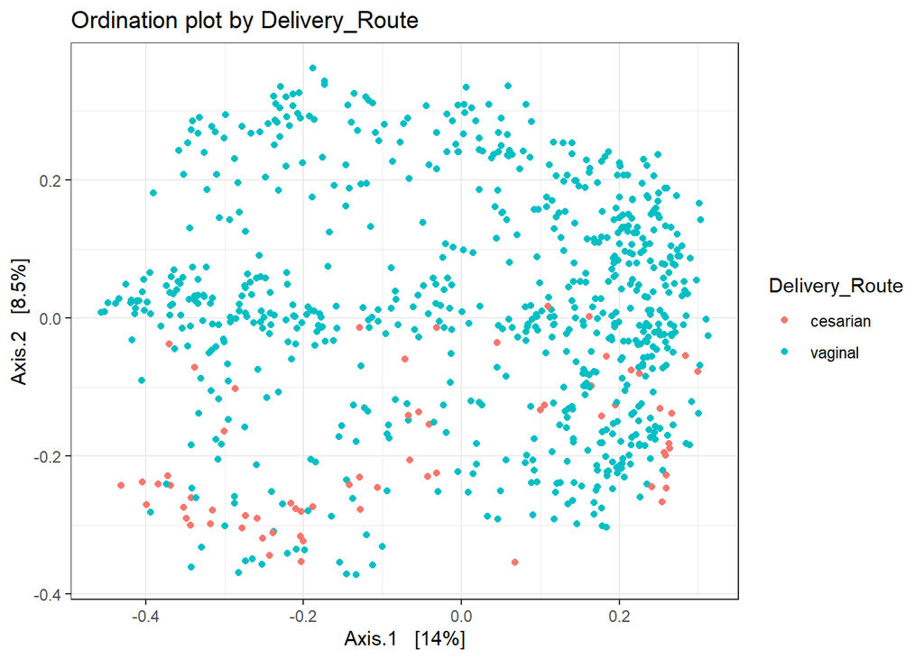

**Differential abundance**

**Graph showing differential abundance**

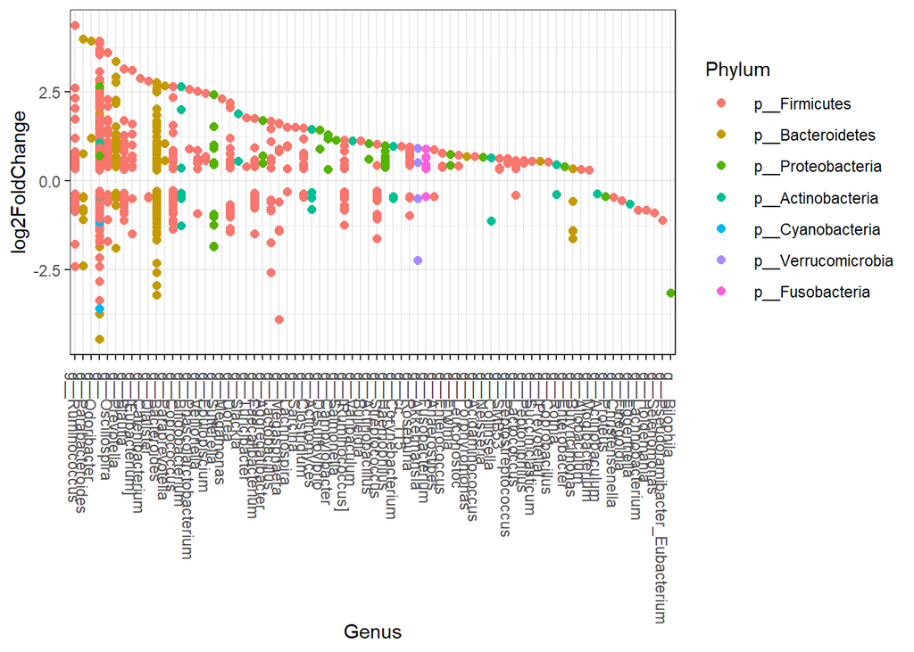